# Yol Analizi

2024-08-05

Yol analizinde sadece **gözlenen değişkenler modellenir.** Bu model **gözlenen değişkenler için bir yapısal eşitlik** modelidir.

Temelde gözlenenen değişkenlerin varyanslarına ve gözlenen değişkenler arasındaki kovaryanslara dayalı olan YEM analizlerinin amacı bir grup gözlenen değişken arasındaki kovaryans örüntüsünü anlamak ve araştırma modeli ile gözlenen değişkenlerin varyanslarını açıklamaktır.

Yol analizi gözlenen değişkenler arasındaki **doğrudan ve doğrudan olmayan etkileri gösteren yapısal modellerin tanımlanmasına** ve test edilmesine izin verir.

**Bir Araştırma Senaryosu: Hastalık Faktörleri**

Sunumdaki örnek Roth, Wiebe, Fillingim ve Shay’in (1989) çalışmasından gelmektedir. Çalışmalarında üniversite öğrencilerinde **egzersiz, dayanıklılık, form ve stresin hastalık üzerindeki etkilerini** incelemişlerdir. “illness.Rds” adlı veri setinde 5 değişken, 400 birey vardır. Değişkenler egzersiz, dayanıklılık, form, stres ve hastalık değişkenleri olup sürekli değişkenlerdir.

Araştırma hipotezleri:

1. egzersiz ve dayanıklılık **formu** etkiler.
2. egzersiz ve dayanıklılık **stresi** etkiler.
3. egzersiz, dayanıklılık, form ve stres **hastalığı** etkiler.

Bu üç hipotezin her biri çoklu regresyon modelidir:

$\text{form}_i = \beta_0 + \beta_{\text{eegzersiz}_i} + \beta_{\text{dayanıklılık}_i} + e_{fi}$

$\text{stres}_i = \beta_0 + \beta_{\text{eegzersiz}_i} + \beta_{\text{dayanıklılık}_i} + e_{fi}$

$\text{hastalık}_i = \beta_0 + \beta_{\text{eegzersiz}_i} + \beta_{\text{dayanıklılık}_i} + \beta_{\text{form}_i} + \beta_{\text{stres}_i} + e_{fi}$

Bu modeller R’da **lavaan paketi** ile model denklemi oluşturularak kullanılmalıdır.

```r
yol_model <-  'stres     ~ egzersiz + dayaniklilik
               hastalik  ~ egzersiz + dayaniklilik + form + stres
               form      ~ egzersiz + dayaniklilik'
```

- Veri setini okuma

```r
hastalik <- readRDS("import/hastalik.Rds")
```

- Yol modelini kurma

```r
library(lavaan)
yol_model <-  'stres     ~ egzersiz + dayaniklilik
               hastalik  ~ egzersiz + dayaniklilik + form + stres
               form      ~ egzersiz + dayaniklilik
               egzersiz  ~~ dayaniklilik'
yol_fit <- sem(yol_model, hastalik)
```

**Dışsal (Exogenous) Değişken:** Nedenleri bilinmeyen ve modelde gösterilmeyen değişkendir. Dışsal değişken değişkenlik göstermekte **serbesttir.** Örneğin, egzersiz ve dayaniklilik

**İçsel (Endogenous) Değişken:** Varsayılan nedenleri modelde açıkça gösterilen değişkendir. İçsel değişken değişkenlik göstermekte **serbest değildir.** Örneğin, form, stres ve hastalık

- Her içsel değişkenin bozukluğu (disturbance) vardır ve bozukluk (disturbance) modelde **D** sembolü ile gösterilir. Bozukluk model için **hata (artık) terimidir** ve **içsel değişkende gözlenen varyansın açıklanmayan kısmını** temsil eder. Model ele alındığında bu nedenlerin doğası ve sayısı bilinmediğinden **bozukluklar gizil değişkenler** olarak düşünülebilir.
- İki dışsal değişken arasındaki analiz edilmeyen ilişki
  - Örneğin, **egsersiz** degişkeni ve **dayanıklılık** değişkeni arasındaki kovaryans
- Bir dışsal değişkenin varyansı
  - Örneğin, **dayanıklılık** değişkeninin varyansı
- Bir bozuklugun varyansı
  - Örneğin, D’nin varyansı

Bir dışsal veya içsel bir değişken diğer bir içsel değişkenin doğrudan nedeni olabilir.

- egzersiz → form
- dayaniklilik → form
- egzersiz → stres
- dayaniklilik → stres
- form → hastalik
- stres → hastalik
- egzersiz → hastalik
- dayaniklilik → hastalik

Bazı **içsel değişkenlerin yol modelinde hem bağımsız hem de bağımlı değişken olarak ikili rolü** vardır. Bu değişkenlere aracı değişkenler adı verilir. Örneğin form, stres

- Aracı değişkenler kendilerinden önceki değişkenlerin nedensel etkilerinin bir kısmını kendilerinden sonraki değişkenlere iletirler, böyle etkilere **dolaylı etkiler** adı verilir.
  - egzersiz → form → hastalik
  - dayaniklilik→ form → hastalik
  - egzersiz → stres → hastalik
  - dayaniklilik → stres → hastalik

## Evren Kovaryans Matrisi

Hastalık faktörleri örneği için gözlenen değişkenlerin evren kovaryans matrisi $\sum$ aşağıdaki gibidir:

$$\begin{bmatrix}{}
VAR_{y_1}\\
COV_{y_2,y_1} & VAR_{y_2}\\
COV_{y_3,y_1} & COV_{y_3,y_2} & VAR_{y_3}\\
COV_{x_1,y_1} & COV_{x_1,y_2} & COV_{x_1,y_3} & VAR_{x_1}\\
COV_{x_2,y_1} & COV_{x_2,y_2} & COV_{x_2,y_3} &
COV_{x_2,x_1} & VAR_{x_2}\\
\end{bmatrix}{}$$

- $\sum$ kare ve simetrik bir matristir ve matriste çoğunlukla alt üçgen ve köşegen öğeleri yazılır.
- bir yol modelindeki gözlenen değişkenler arasındaki varyans ve kovaryanslardır.
- Model gözlemlerinin sayısı $v$ gözlenen değişkenlerin sayısı olmak üzere $v(v + 1) / 2$’ye eşittir.
- hastalık faktörleri örneğine göre, $v = 5$ ve $v(v + 1) / 2 = 15$

Modelden kestirilen parametre sayısı

- ya gözlenen ya da gözlenmeyen **dışsal değişkenlerin varyanslarının ve kovaryanslarının sayısı** ve
- **gözlenen değişkenlerden içsel değişkenlere olan doğrudan etkilerin sayısı** toplamıdır.
- Hastalık faktörleri örneğinde, kestirilecek model parametreleri:
- Dışsal değişkenlerin varyansları: 2
- Dışsal değişkenlerin kovaryansı: 1
- Bozuklukların varyansları: 3
- Doğrudan etkiler: 8

$2 + 1 + 3 + 8 = 14$

**İçsel değişkenlerin varyansları ve kovaryansları model parametreleri olarak ele alınmaz.**

**Bozukluk, modelde nedeni bilinmediğinden, gözlenmeyen dışsal değişken olarak ele alınır.**

- **Model serbestlik derecesi (sd)** model gözlemlerinin sayısı ve modelden kestirilecek parametre sayısı arasındaki farka eşittir:
- Hastalık faktörleri örneğinde,

$$sd = 15 – 14 = 1$$

- **sd<0** model tanımlanamaz.
  - Gözlem eksikliğinin tanımlanmamaya nasıl yol açtığının bir örneği $a + b = 6$. Verilen eşitlik bir model olarak ele alınırsa, **6 gözlem**, **a ve b de parametrelerdir.** Eşitlikte **parametre sayısı (2)**, **gözlem sayısından (1)** daha fazla olduğundan,her bir parametre için tek bir çözüm bulmak imkansızdır. **a ve b** parametreleri için eşitliği sağlayacak sonsuz sayıda çözüm vardır: - Örneğin, (a = 4, b = 2), (a = 8, b = -2) vb.
  - **Yetersiz tanımlanan bir yol modeli için** program **her bir parametreye ait tek bir kestirim üretmeye** çalışırken de benzer bir durum söz konusudur.
  - Yetersiz tanımlanan bir model test edilemez ve yeniden tanımlanması gerekir. Bu durumda en az bir parametrenin çözümü yoktur.

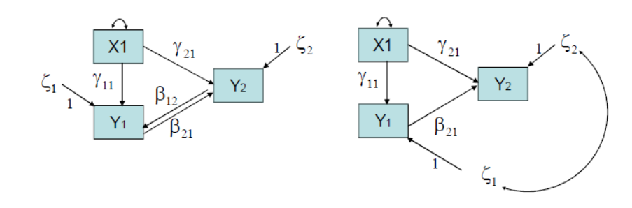

- **sd=0** model ancak tanımlanır (just identification) ve kuramsal olarak her parametrenin tek bir çözümü vardır. Model veriye mükemmel uyum gösterir. Ancak tanımlanmanın model için iki eşitlik verilsin $a + b = 6$ , $2a + b =10$ verilen eşitlikler bir model olarak ele alınırsa, **6** ve **10** **gözlemler**, **a** ve **b de parametrelerdir.** Eşitlikte **parametre sayısı (2)**, **gözlem sayısına (2)** eşit olduğundan,her bir parametre için tek bir çözümü bulunmaktadır. (a = 4, b = 2)
  - Parametre kestirimleri verildiğinde gözlemler mükemmel bir şekilde üretilir. Ancak tanımlanan bir yol modeli için program her bir parametreye ait tek bir kestirim üretmekle kalmayıp **model veriye mükemmel uyum** sağlayacaktır. Ancak tanımlanan bir modelde **parametre sayısı ve gözlem sayısı** birbirine eşittir, diğer bir ifadeyle modelin serbestlik derecesi sıfıra eşittir (sd = 0) ve model tanımlanır; kuramsal olarak her parametrenin tek bir çözümü vardır.

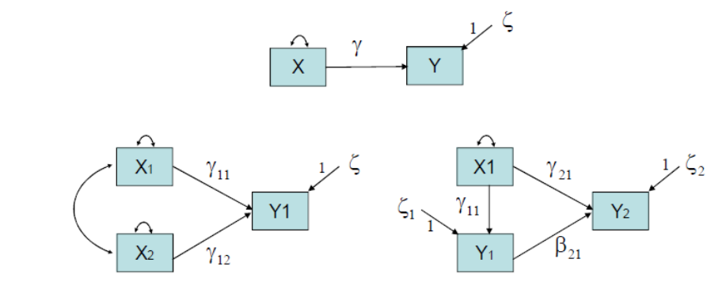

- **sd>0** model aşırı tanımlanmış (over identification) olur. Aşırı tanımlanan modellerde kuramsal olarak her bir parametrenin birden fazla çözümü vardır. **Kuramsal olarak ifadesi tanımlanmanın verinin değil, modelin bir özelliği** olduğunu vurgulamak için kullanılmıştır.
  - Örneğin, **eğer bir model tanımlanmazsa**, **örneklem büyüklüğüne (100, 1000, vb.) bağlı olmaksızın** tanımlanamaz olarak kalır. Bu nedenle, **tanımlanmayan modellerin yeniden tanımlanması** gerekir. Aksi halde, **analizler çözüm** üretmez.
  - Aşırı tanımlanan bir modelde **parametre sayısı, gözlem sayısından küçüktür**, diğer bir ifadeyle modelin serbestlik derecesi sıfırdan büyüktür **sd > 0**, kuramsal olarak her parametrenin olası bir çok çözümü vardır.

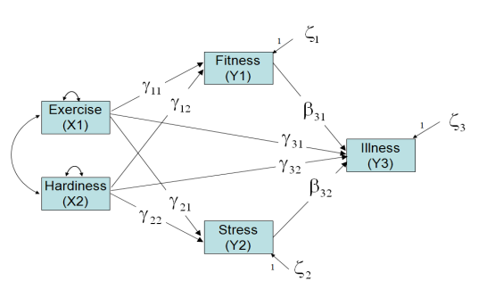

    - Aşırı tanımlanan bir model için, üretilen kovaryans matrisi örneklem kovaryans matrisini **mükemmel bir şekilde üretmeyecektir.** Aşırı tanımlanmanın model örneği için üç eşitlik verilsin $a + b = 6$ , $2a + b =10$, $3a + b = 12$ Verilen eşitlikler bir model olarak ele alınırsa, **6, 10 ve 12** gözlemler, **a ve b de parametrelerdir.** Üç eşitliği sağlayacak **a ve b değerleri bulunmayabilir.** Örneğin, (a = 4, b = 2) değerleri sadece ilk iki eşitliği sağlar. Aşırı tanımlama durumda, her bir parametre için tek bir çözüm aşağıdaki şekilde üretilir:
  - Gözlemler ve üretilen gözlemler arasındaki farkın karesinin toplamının mümkün olduğunca küçük olacağı pozitif parametre değerleri bulunur. Örneğin, (a = 3, b = 3,3) sadece en küçük toplam kareler farkını sağlamakla kalmaz tek bir çözüm üretir.
- Herhangi bir yapısal eşitlik modeli için tanımlanmanın gerektirdiği iki koşul vardır:
  - Her **gözlenmeyen (gizil) değişken bir ölçeğe atanmalıdır,** bozukluk yol analizindeki tek gizil değişkendir.
  - **En az serbest model parametreleri kadar gözlem olmalıdır (sd ≥ 0)**

## Model-Veri Uyumunun Değerlendirilmesi

Kestirilen parametre sayısından daha fazla sayıda gözleme sahip olan **aşırı tanımlanan** (overidentified) modeller **genellikle veriye mükemmel uyum sağlamaz.** Bu durumda böyle modellerin veriyle ne derece uyumlu olduğunu ölçmeye ihtiyaç vardır.

YEM literatüründe tanımlanan **çok sayıda model uyum indeksi vardır** ve sürekli olarak yeni indeksler geliştirilmektedir. Çok sayıda farklı uyum indeksinin olması bazı problemleri de beraberinde getirir:

- Farklı makalelerde farklı uyum indeksleri rapor edilir.
- Aynı makale için farklı hakemler kendi bildikleri veya tercih ettikleri farklı indekslerin rapor edilmesini isteyebilirler.

Uyum indekslerinin değerlerini rapor ederken seçici davranma olasılığı vardır (örneğin, sadece iyi uyum öneren uyum indekslerinin rapor edilmesi gibi).

YEM uygulamalarına ve simülasyon çalışmalarına göre YEM analizinin sonuçlarını rapor ederken sunulacak ve yorumlanacak uyum indeksleri aşağıdaki gibidir:

- Model **Ki-Kare** Değeri
- Steiger-Lind Root Mean Square Error of Approximation **RMSEA** (Steiger, 1990) (%90 güven aralığı ile birlikte)
- Bentler Comparative Fit Index **CFI** (Bentler, 1990)
- Standardized Root Mean Square Residual **SRMR**

Uyum indekslerinin değerleri bir modelin sadece ortalama veya genel uyumunu belirtir. Bu nedenle **belli bir indeksin değeri uygun bile görünse, modelin belli kısımları veriye zayıf uyum sağlayabilir.**

- Uyum indeksleri sonuçların **kuramsal olarak anlamlı olup olmadığını belirtmezler.**
- Örneğin, bazı yol katsayılarının işaretleri beklenenin aksi yönde olabilir. Uyum indekslerinin değerleri uygun bile görünse **beklenmeyen sonuçlar açıklama gerektirir.**
- Yeterli uyumu öneren uyum indekslerinin değerleri **yordayıcıların yordama güçlerinin de yüksek olduğunu belirtmezler.**
- Örneğin, **veriye mükemmel uyum sağlayan modellerin bozukluklarının varyansı halen yüksek olabilir.**
- **Tek bir indeks** modelin sadece belli bir yönünü yansıttığından,modelin iyi uyum sağladığını belirtmek için **tek başına yeterli olmaz.** Bu nedenle, model uyumu birden fazla indeksin değerine dayanarak değerlendirilir. **Çoklu indekslerin kullanılması** bir modelin uyumu ile ilgili **en doğru yaklaşımı verecektir.**
- **Ancak tanımlanan** (just identified) bir model için ki-kare değeri genellikle sıfıra eşittir ve serbestlik derecesi yoktur **sd = 0**. Eğer model ki-kare değeri sıfıra eşitse model **veriye mükemmel bir şekilde** uyar (kestirilen korelasyon ve kovaryans değerleri gözlenenlere eşittir).
- Model **ki-kare değeri arttıkça**, modelin veriye uyumu kötüleştiği için model ki-kare aslında bir **kötülük uyum** indeksidir. Geleneksel hipotez testinin aksine, ki-kare testinin sıfır hipotezinin **reddedilmemesi** tercih edilir. **Sıfır hipotezinin reddedilmemesi modelin veriye uyduğunu önerir.** Diğer yandan sıfır hipotezinin reddedilmesi **model-veri uyumunun iyi olmadığını önerir.**
- Tek bir indeks model uyumunun sadece belli bir yönünü yansıtır. Araştırmacılar aşağıdakilerin rapor edilmesini önerir:

| Uyum indeksi | İyi uyum | Kabul Edilebilir Uyum |
| --- | --- | --- |
| $\chi^2$ | p |  |
| $\chi^2/df$ | 0 ≤ $\chi^2/df$ ≤ 2 | 2 < $\chi^2/df$ < 8 |
| SRMR | 0 ≤SRMR ≤ .05 | .05 < SRMR < .08 |
| RMSEA | 0 ≤RMSEA ≤ .05 | .05 < RMSEA < .08 |
| CFI | .95 ≤GFI ≤ 1 | .90 < GFI < .95 |

Not: Bu kesme değerlerin kullanılmasıyla ilgili çok sayıda tartışma vardır.

- Önerilen uyum indeksleri göz önüne alınınca model-veri uyumu ile ilgili ne söylenebilir?

```r
fitmeasures(yol_fit,fit.measures = c("chisq" ,"df" ,"pvalue",
                                     "cfi","tli","rmsea",
                                     "rmsea.ci.lower","rmsea.ci.upper"
                                     ,"srmr"))
```

```
##          chisq             df         pvalue            cfi            tli
##         12.307          1.000          0.000          0.948          0.485
##          rmsea rmsea.ci.lower rmsea.ci.upper           srmr
##          0.168          0.093          0.258          0.043
```

### Bireysel İstatistiksel testler

Bireysel istatistiksel test belli parametre kestirimlerine dayalı hesaplanır. Hatalı tanımlamanın değerlendirilmesinde kullanışlıdır.

t-değeri = parametre kestirimi / standart hata

- Normal olarak dağılır.
- z-istatistiği gibi kullanılır.
- Parametrelerin beklenen yönde olup olmadığını ve istatistiksel olarak sıfırdan farklı olup olmadığını değerlendirir.

Anlamlı olmayan parametreler 0’a sabitlenebilir ancak test **n** ile ilişkilidir. Ancak bir parametrenin sabitlenmesi diğer bütün kestirimleri değiştirecektir. Bu da hatalı tanımlamadan dolayı hatalara sebep olabilir

### Standartlaştırılmış Artık

İdeal olarak **artık değerleri küçük ve tek biçimli olmalıdır.** Artık kovaryans matrisini yorumlamak standartlaştırılmış artık kovaryans matrisinden daha zordur.

Standartlaştırılmış artık:

- z-puanları gibidir.
- Hangi değerin büyük olduğunu belirlemek kolaydır (0.05 alfa düzeyinde 1.96 istatistiksel anlamlılık)
- Köşegen dışındaki standartlaştırılmış artıkların mutlak değerlerinin ortalaması tipik bir artığı temsil eden bir indeks sağlar.

```r
# lavResiduals(yol_fit)
# resid(yol_fit)
resid(yol_fit, type='normalized')
```

```
## $type
## [1] "normalized"
##
## $cov
##               stres hastlk   form egzrsz dynkll
## stres         0.002
## hastalik      0.718  0.392
## form         -2.950 -1.031  0.006
## egzersiz     -0.021 -0.011  0.010  0.000
## dayaniklilik -0.005 -0.005  0.025  0.067  0.000
```

Standarlaştırılmış hata kovaryans matrisinde yer alan diyagonal dışındaki her bir değerin mutlak değerinin 1.96’dan küçük olması beklenir.

### Modifikasyon İndeksleri

**modindices** fonksiyonu ile modifikasyon indeksleri istenebilir. **mi** sütunu yapılacak modifikasyon sonucunda ki-karedeki düşüsü göstermektedir.

```r
modindices(yol_fit, sort = TRUE)
```

```
##      lhs op      rhs     mi    epc sepc.lv sepc.all sepc.nox
## 24 stres  ~ hastalik 12.115  0.799   0.799    0.693    0.693
## 25 stres  ~     form 12.115 -0.326  -0.326   -0.180   -0.180
## 26  form  ~    stres 12.115 -0.093  -0.093   -0.168   -0.168
## 27  form  ~ hastalik 12.115 -0.296  -0.296   -0.464   -0.464
```

```r
## modindices(yol_fit, sort = TRUE, maximum.number = 5)
```

Bu tablo dört parametreden herhangi birinin (aynı anda, eş zamanlı DEĞİL) model ki-kare değerini 12.1 değerinde düşüreceğini önermektedir. Artık kovaryans matrisinden gelen kanıt da birleştirildiğinde, modele **form değişkeninin stres değişkenine** doğrudan etkisini gösteren bir parametre eklenebilir

Bu model ancak tanımlanan modeldir (sd = 0), bu nedenle veriye mükemmel uyum sağlayacaktır

## Modelin Yeniden Tanımlanması

**Revised Model 1**

- stres ~ form yolu eklenir.

```r
yol_model_v1 <-
'stres     ~ egzersiz + dayaniklilik
hastalik  ~ egzersiz + dayaniklilik + form + stres
form      ~ egzersiz + dayaniklilik
stres     ~ form
egzersiz ~~ dayaniklilik'
yol_fit_v1 <- sem(yol_model_v1, hastalik)
```

```r
fitmeasures(yol_fit_v1,fit.measures=c("chisq","p","df"))
```

```
## chisq    df
##     0     0
```

```r
p_pa_1 <- semPaths(yol_fit_v1, whatLabels = "est",
sizeMan = 10,
edge.label.cex = 1.15,
style = "ram",layout = "spring" ,
nCharNodes = 0, nCharEdges = 0)
```

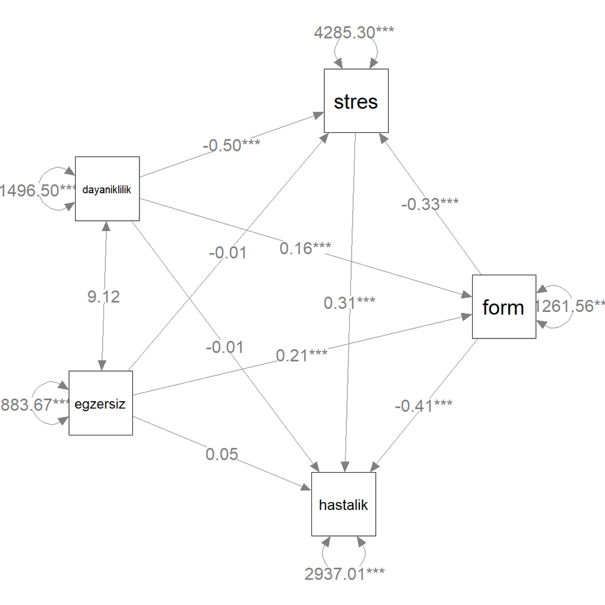

```r
p_pa_1 <- semptools::mark_sig(p_pa_1, yol_fit_v1)
plot(p_pa_1)
```

**Revised Model 2**

- anlamlı olmayan yol katsayıları kaldırıldır

```r
yol_model_v1 <-
'stres     ~ egzersiz + dayaniklilik
hastalik  ~ egzersiz + dayaniklilik + form + stres
form      ~ egzersiz + dayaniklilik
stres     ~ form
egzersiz ~~ dayaniklilik'


yol_model_v2 <-
'stres     ~  dayaniklilik
hastalik  ~ form + stres
form      ~ egzersiz + dayaniklilik
stres     ~ form
egzersiz ~~ dayaniklilik'
yol_fit_v2 <- sem(yol_model_v2, hastalik)
```

- anlamlı olmayan yol katsayıları kaldırıldır

```r
fitmeasures(yol_fit_v2,c("rmsea","cfi","srmr"))
```

```
## rmsea   cfi  srmr
## 0.000 1.000 0.011
```

```r
m <- matrix(c(NA, NA, "form",  NA,   NA,
              "egzersiz", NA, NA,  NA,   NA,
                NA, NA, NA,  NA, "hastalik",
              "dayaniklilik",    NA, NA,  NA,   NA,
                NA, NA, "stres",  NA, NA

              ), byrow = TRUE, 5, 5)

p_pa_2 <- semPaths(yol_fit_v2, whatLabels = "est",
           sizeMan = 10,
           edge.label.cex = 1.15,
           style = "ram",
           nCharNodes = 0, nCharEdges = 0,
           layout=m)
```

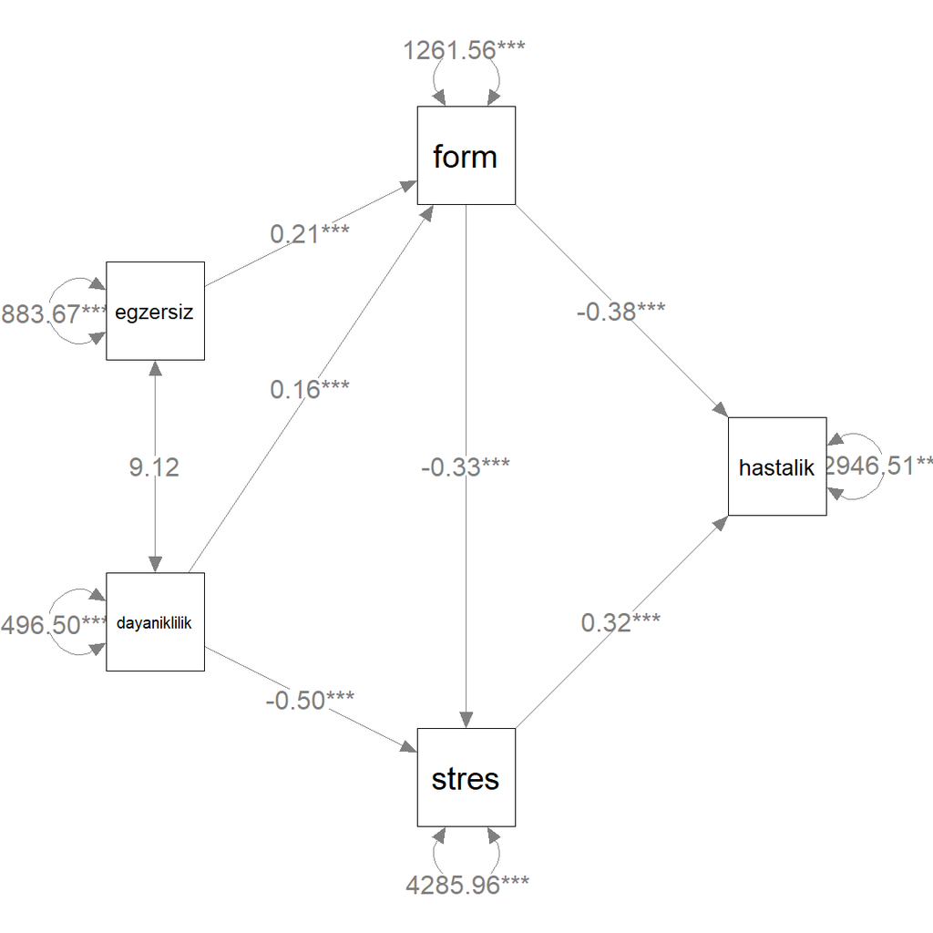

```r
p_pa_2 <- semptools::mark_sig(p_pa_2, yol_fit_v2)
plot(p_pa_2)
```

```r
fitmeasures(yol_fit_v2,fit.measures = c("chisq" ,"df" , "pvalue",
                                        "cfi","tli","rmsea",
                                        "rmsea.ci.lower",   "rmsea.ci.upper"
                                        ,"srmr"))
```

```
##          chisq             df         pvalue            cfi            tli
##          1.354          3.000          0.716          1.000          1.025
##          rmsea rmsea.ci.lower rmsea.ci.upper           srmr
##          0.000          0.000          0.061          0.011
```

sd = 3 için ki-karenin 0.05 alfa düzeyindeki kritik değeri 7.82’dir. 1.354 değeri 7.82 değerinden küçük olduğundan gözlenen ki-kare değeri (1,354) 0.05 alfa düzeyinde istatistiksel olarak anlamlı değildir.

- RMSEA, CFI ve SRMR indekslerinin değerleri istenilen değerdedir

### Ki-Kare Fark Testi

Hem model 1 hem de model 2 veriye iyi uyum sağlamaktadır.

- Bu durumda hangi model seçilmelidir?
  - **Mükemmel uyum** sağlayan ancak daha karmaşık model mi?
  - **İyi uyum sağlayan** ancak daha basit model mi?

Ki-kare fark testi hiyerarşik olarak kümelenmiş iki modelin karşılaştırılmasında oldukça kullanışlıdır. Eğer modellerden birisi diğerinin alt kümesiyse iki model kümelenmiştir (daha basit model daha karmaşık modelin içinde kümelenmiştir).

- Bu durumda model 2 (daha basit model) model 1 (daha karmaşık model) içinde kümelenmiştir.

Ki-kare fark testi modellerin bağıl uyumlarını değerlendirmek için kullanılabilir. İki model de veriye iyi uyum sağladığında, ki-kare değerleri arasındaki fark serbestlik derecesi iki model arasındaki parametre sayısındaki farka eşit olan ki-kare dağılımı gösterir:

- $\chi^2_{dif} = \chi^2_{simple} -\chi^2_{complex}$
- $df_{dif} = df_{simple} - df_{complex}$

Anlamlı olmayan ki-kare farkı daha basit modelin daha karmaşık modelden istatistiksel olarak veriye daha kötü uymadığını önerir. Bu nedenle, daha basit model daha tutumlu olduğundan dolayı seçilmelidir. Aksi halde karmaşık model seçilmelidir.

Örnekte model 2 (12 model parametresine sahip olup sd = 3) model 1’den (15 model parametresine sahip olup sd = 0) daha basittir.

- $\chi^2_{dif} = \chi^2_{simple} -\chi^2_{complex}$
- $df_{dif} = df_{simple} - df_{complex}$

1.354 ki-kare değeri sd = 3 olduğunda, 0,05 alfa düzeyinde (kritik ki-kare değeri = 7.82) istatistiksel olarak **anlamlı değildir.** Bu nedenle revised model 2 (daha basit olan) revised model 1’e (daha karmaşık olan) tercih edilir şeklinde sonuca varılabilir

### AIC ve BIC

Akaike Information Criterion (AIC) ve Bayesian Information Criterion (BIC) evren dayanaklı yordayıcı uyum indeksleri olarak bilinir. Farklı YEM yazılımları AIC ve BIC değerlerini farklı şekilde hesaplayabilir.

- AIC ve BIC değerleri çoğunlukla aynı veriden kestirilen hiyerarşik olmayan modellerin arasından seçim yapmak için kullanılır. Bağıl olarak daha küçük değerler uygundur

model1

```r
fitmeasures(yol_fit_v1,fit.measures = c("AIC","BIC"))
```

```
##      aic      bic
## 21422.85 21482.72
```

model2

```r
fitmeasures(yol_fit_v2,fit.measures = c("AIC","BIC"))
```

```
##     aic     bic
## 21418.2 21466.1
```

İki model kümelenmiş modeller olduğundan, iki model arasında AIC ve BIC değerlerinin **karşılaştırılmasına gerek yoktur**

Eğer model-veri uyumu zayıfsa, ilk olarak varsayılan model veriye uymaz. Eğer model-veri uyumu iyiyse, model veri tarafından desteklenir. Alternatif modelleri araştırmak veya **daha tutumlu (parsimonious) bir model aramak için ilave analizler yürütülebilir.** Mükemmel veya iyi bir model-veri uyumu mutlaka modelin iyi olduğunu önermez. İyi bir model en basit şekilde olan (tutumluluk ilkesi), ama hala veriye iyi uyan modeldir.

**İyi Uyuma karşı Model Tutumluluğu**

## Model Sonuçlarının Rapor Edilmesi

- MODEL bölümü modelin belirlenmesi
- Yol analizinde, her bir içsel (endogenous) değişkenin bir veya daha fazla değişken tarafından yordanması $~$ ifadesi ile belirtilir.
- Örneğin, **form~egzersiz + dayaniklilik** ifadesinin anlamı form’ın egzersiz + dayaniklilik tan yordandığıdır. ham veri kullanıldığı zaman, default modeli değişkenler için ortalamaların/kesişimlerin kestirildiği ortalama yapıları içerecektir.
- Yol analizi modeli için kovaryans yapısına odaklanılır. “Means” ve “Intercepts” bölümü altındaki değerler göz ardı edilir.
- Ortalamalar/kesişimler çıkarılınca, kestirilen **parametre sayısı 14** olmalıdır.

```r
summary(yol_fit,rsquare=TRUE,standardized =TRUE)
```

[output not shown]

Her bir kestirimin yorumu çoklu regresyondaki yorumlara benzerdir.

Not: Her bir içsel değişken için $R^2$ değeri ve standartlaştırılmış artık varyansının toplamı “1”e eşit olmalıdır: 0.164 + 0.836 = 1

```r
library(knitr)
library(dplyr)
standardizedsolution(yol_fit) %>%
  filter(op == "~") %>%
  select('Bağımlı Değişkenler'=lhs, Gosterge=rhs,
         B=est.std, SE=se, Z=z, 'p-value'=pvalue) %>%
  knitr::kable(digits = 3, booktabs=TRUE, format="markdown",
               caption="Yol Analizi Sonuçları")
```

Yol Analizi Sonuçları

| Bağımlı Değişkenler | Gosterge | B | SE | Z | p-value |
| --- | --- | --- | --- | --- | --- |
| stres | egzersiz | -0.080 | 0.047 | -1.683 | 0.092 |
| stres | dayaniklilik | -0.307 | 0.045 | -6.802 | 0.000 |
| hastalik | egzersiz | 0.054 | 0.048 | 1.116 | 0.264 |
| hastalik | dayaniklilik | -0.007 | 0.048 | -0.138 | 0.891 |
| hastalik | form | -0.260 | 0.048 | -5.474 | 0.000 |
| hastalik | stres | 0.362 | 0.044 | 8.165 | 0.000 |
| form | egzersiz | 0.371 | 0.043 | 8.721 | 0.000 |
| form | dayaniklilik | 0.160 | 0.045 | 3.544 | 0.000 |

## Model Karşılaştırmalarının Rapor Edilmesi

```r
library(semoutput)
sem_anova(yol_fit_v2,yol_fit_v1)
```

Model Comparison

| term | df | AIC | BIC | statistic | Chisq.diff | RMSEA | Df.diff | p.value |
| --- | --- | --- | --- | --- | --- | --- | --- | --- |
| 1 | 3 | 21418.20 | 21466.10 | 1.354 | 1.354 | 0 | 3 | 0.716 |
| 2 | 0 | 21422.85 | 21482.72 | 0.000 | NA | NA | NA | NA |

```r
sem_modelcomp(yol_fit_v2,yol_fit_v1)
```

Model Comparison

| Model | df | AIC | BIC | BF | P(Model\|Data) | χ<sup>2</sup> | Δχ<sup>2</sup> | Δdf | p |
| --- | --- | --- | --- | --- | --- | --- | --- | --- | --- |
| yol_fit_v2 | 3 | 21418.199 | 21466.096 | 4065.263 | 1.000 | 1.354 |  |  |  |
| yol_fit_v1 | 0 | 21422.845 | 21482.717 | 0.000 | 0.000 | 0.000 | 1.354 | 3.000 | 0.716 |

## Doğrudan, Dolaylı ve Toplam Etkiler

**Toplam etki**, bir değişken bir birim değiştiğinde diğer bir değişkenin ne kadar değişeceğini belirtir.

Toplam etkinin iki bileşeni olabilir: doğrudan etki ve bazı araya giren değişkenler üzerinden dolaylı etkiler

- Bir değişkenin diğer bir değişken üzerindeki doğrudan etkisi yol modelindeki ağırlığıyla belirtilir.
- Dolaylı etkiler doğrudan etkilerin çarpımları olarak istatistiksel olarak kestirilir.
- Doğrudan ve dolaylı etkiler ya standartlaştırılmamış ya da standartlaştırılmış çözümlerin sonuçlarına dayanarak hesaplanabilir.
  - Ancak, eğer değişkenlerin birbirlerine göre etkileri karşılaştırılacaksa **standartlaştırılmış çözümler kullanılmalıdır.**
- Egzersiz, hastalık üzerinde doğrudan etkiye sahiptir; bu doğrudan etkinin standartlaştırılmış değeri 0.054’tür.
- Egzersiz, hastalık üzerinde iki tane de dolaylı etkiye sahiptir; biri form üzerinden, diğeri ise stress üzerindendir. Dolaylı etki, ilgili standartlaştırılmış yol katsayılarının çarpılması sonucu elde edilir:
  - Egzersiz → Form → Hastalık: (0.371)(-0.260) = -0.096
  - Egzersiz → Stres → Hastalık: (-0.080)(0.362) = -0.029
- Böylece egzersiz’in hastalık üzerindeki toplam etkisi:
  - toplam etki = doğrudan etki + toplam dolaylı etki
  - = 0.054 + (-0.096) + (-0.029)
  - = 0.054 + (-0.125)
  - = - 0.071

egzersiz → form → hastalık

egzersiz → stres → hastalık

dayanıklılık → form → hastalık

dayanıklılık → stres → hastalık

```r
yol_model <-  'stres     ~ s_e*egzersiz + dayaniklilik
               hastalik  ~ h_e*egzersiz + dayaniklilik + h_f*form + h_s*stres
               form      ~ f_e*egzersiz + dayaniklilik
               egzersiz ~~ dayaniklilik

               # Direct Effect
               dir_fm:=h_f
               dir_sh:=h_s

               # InDirect Effect
               ind_h1:=f_e*h_f
               ind_h2:=s_e*h_s

               # total InDirect Effect
               tot_ind:=ind_h1 +  ind_h2

               # Total Effect
               tot:=tot_ind + h_e'

fsem1 <- sem(yol_model,hastalik)
```

```r
param_estimates <- standardizedsolution(fsem1)
```

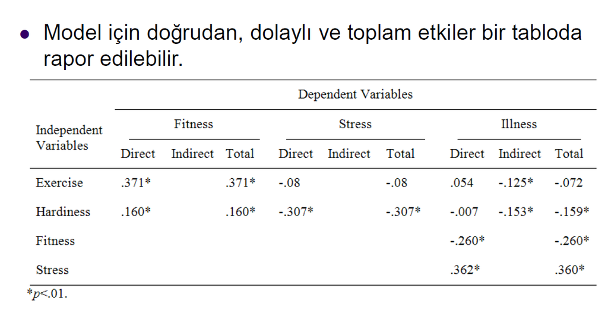

## Olası model sorunları ve çözüm yolları

- Model tanımlama ilk ve en önemli adımdır. Model tanımlanmayabilir(sd<0), bu durumda uyum indeksleri de hesaplanamaz. Veri ile ilgili bir düzeltme bu sorunu çözmez, analizlerin devam ettirilebilmesi için modelin yeniden tanımlanması gerekir.
- Literatüre göre model belirlenmelidir.
- Modelde yer alan değişken sayısı artırılabilir.
- Model aşırı tanımlanabilir (sd>0), bu durumda model kestirimi yapılabilir ya da model hatalı olabilir. Genelde veriye mükemmel uyum sağlamazlar. Bu durumda her bir parametre için en uygun tek bir çözüm üretilmeye çalışılır.
- Model veri uyumunun sağlandığı birden çok model ele alınabilir ve tutumluluk ilkesi gereği ek analizler ile en uygun model seçilmelidir.
- Model veri uyumunda çoklu indeksler değerlendirilmelidir.

-Literatürde yaygın olarak kullanılan model uyum indeksleri yukarıda detaylı olarak verilmişti. Fakat bu indeksler birçok değişkenden etkilenebilir ve her sıklıkla kullanılan sabit kesme değerler bazı modeller için yanıltıcı olabilir. Örneğin Model veri uyumu indeksleri özellikle örneklem büyüklüklerinden önemli derecede etkilenir. Örneğin CFI, GFI gibi değerler küçük örneklemlerde sabit kesme değerlerden düşük çıkma eğiliminde olduğundan doğru modelleri uyumlu göstermeyebilir. Benzer şekilde daha az modeller de büyük örnemlerde sabit kesme değerlerden yüksek çıkabilir. Bu durumda esnek kesim noktaları model boyutuna, faktör yüklerine, örneklem büyüklüğüne ve dağılım normalliğine göre belirlenir. Esnek kesme noktaları, belirli bir ampirik modelin ideal modele ‘yakın’ olup olmadığını gösterir. Burada dikkat edilmesi gereken esnek kesme noktaları belirlenirken güven aralığının çok geniş (α = .1) ve çok düşük (.001) seçilmemesidir. Bu tür hata aralıkları, değerlendirilen model hakkında çok yüksek ve çok düşük belirsizlik varsayar. Esnek kesim noktalarını beliirlemek amaçıyla R yazılımında FCO paketi geliştirilmiştir. Paket, belirli bir veri kümesine ve modele dayalı uyum endekslerini simüle eder ve ardından esnek kesme değerlerini tahmin eder.

- Model veri uyumunu sağlamak ya da güçlendirmek için modele belirli bir parametre eklenerek modelin kikare istatistiğinin düşürülmesinde modifikasyon indeksleri kullanılır. Fakat burada dikkat edilmesi gereken nokta istatistiksel uyumdan ziyade modifikasyınların teorik kurama uygun kullanılması gerektiğidir.
- Örneklem büyüklüğü yeterli olmalıdır.ML yöntemi ile kestirim yapılacaksa minimum örneklem büyüklüğü için birim sayısının modelde kestirilecek parametre sayısına oranı en az 20 olmalı iken model karmaşıklaştıkça ya da normallik sağlanmayıp başka kestirim yöntemleri kullanıldığında bu oran yeterli olmayacaktır.Örneğin ; örneklem büyüklüğünün 250 veya daha az olduğu normal olmayan dağılım gösteren verilerin ML kestirimine dayalı uyum indekslerinin doğru tanımlanmış modeli reddetme eğiliminde olabilir.
- Varsayımlar (uç değer, doğrusallık,çoklu bağlantı, normallik, eş varyanslık) kontrol edilmelidir. Bu varsayımlar sağlanmazsa, model-veri uyumu, parametre kestirimleri ve kestirimlerin standart hataları açısından yanlı sonuçlar üretilebilir. Bunun durum model ile ilgili yanlış kararlar alınmasına sebep olur.
- Normal teori kestirim yöntemlerinden yaygin olarak kullanılan iki tanesi maksimum olabilirlik (maximum likelihood – ML) ve genelleştirilmis en küçük kareler (generalized least squares – GLS) kestirim yöntemleridir. Eğer model doğru tanımlanmazsa, diğer varsayımlar karşılansa bile, ML yöntemiyle kestirilen parametreler ve elde edilen uyum indeksleri GLS yöntemiyle kestirilen parametrelerden ve elde edilen uyum indekslerinden farklı olacaktır.
- Normal dağılım göstermeyen veya kategorik veriler modellenirken parametre kestirim yöntemleri değiştirilebilir. Uygun kestirim yönteminin seçilmesi, aslında verinin özelliklerine ve çalışma desenine bağlıdır.
- Normal dağılım göstermeyen veya kategorik veriler modellenirken parametre kestirim yöntemleri değiştirilebilir. Uygun kestirim yönteminin seçilmesi, aslında verinin özelliklerine ve çalışma desenine bağlıdır. Gözlenen veride sergilenen çok değiskenli basıklık düzeyine dayalı bir faktör tarafından ML dayanaklı ki-karenin ve standart hataların uyarlanmasını içeren yöntemler (Örneğin, Satorra-Bentler (S-B) ölçekli ki-kare ve standart hatalar) seçilebilir. Veri yaklaşık olarak normal dağılım gösterdiğinde ve sıralı kategorilerin sayısı en az dörtse, Satorra-Bentler (S-B) ölçekleme yöntemleriyle MLR kestirimi önerilir.Ayrıca en küçük kareler kestirimleri olan ULS, WLS, DWLS yöntemleri de normallik varsayımı ihlaline karşı kullanılabilir.
- Kategorik verilerin sürekli veriler gibi ele alınması da ciddi sorunlara sebep olur. Parametre kestirimlerinin ve uyum indekslerinin kategori sayısı en az 4’se nispeten dayanıklıdır. Kategori saysı 4’ten az, örnek büyüklüğü de az ise bu durum ki-kare değerinde şişmelere neden olur. Veri normal dağılım göstermediğinde, kategori sayısı dörtten azsa ve özellikle örneklem büyüklüğü büyükse, yapay dağılım serbest kestirim (arbitrary distribution free estimation (ADF)) yöntemi önerilir. Ancak ADF büyük örneklem gerektirir ve model karmaşıklaştıkça performansı kötüleşir. WLS yöntemi kadar büyük örneklem gerektirmeyen dayanıklı WLS (robust WLS) yöntemleri önerilmiştir. Ayrıca normal dağılım sağlanmadığı durumlarda madde gruplaması ve parsellemesi de yapılabilir.

## Kaynaklar

- Roth, D. L., Wiebe, D. J., Fillingim, R. B., & Shay, K. A. (1989). Life events, fitness, hardiness, and health: A simultaneous analysis of proposed stress-resistance effects. *Journal of Personality and Social Psychology, 57*(1), 136-142.
- Bentler, P. M. (1990). Comparative fit indexes in structural models. *Psychological Bulletin, 107,*238-246.
- Steiger, J. H. (1990). Structural model evaluation and modification: An interval estimation approach. *Multivariate Behavioral Research, 25,* 173-80.
- Bentler, P. M. & Hu, L. (1999). Cutoff criteria fpr fit indexes in covariance structure analysis: Conventional criteri versus new alternatives. *Structural Equation Modeling, 6*(1), 1-55.
- Marsh, H. W., & Hau, K. T. (2007). Applications of latent-variable models in educational psychology: The need for methodological-substantive synergies. *Contemporary educational psychology, 32*(1), 151-170.